# assignment 11/4

# Part 4: Building a Linear Regression Model

    ```r
    model = lm(Ozone ~ . , data = airquality)
    ```

13. I used the code above to fit a linear model using ozone as the response variable and all other variables as predictors.
14. The coefficient tells us the effect that the predictor variable has ozone. If the coefficient for a predictor variable is positive, it means as that variable increases so does ozone. R-Squared tells us how good of a fit the model is to the data set. If the R-squared is low, the model explains the variance in the response variable well. P-values tell us if a variable is significant in explaining ozone.

    ```r
    augmented_data <- augment(model, data = airquality)
    ```

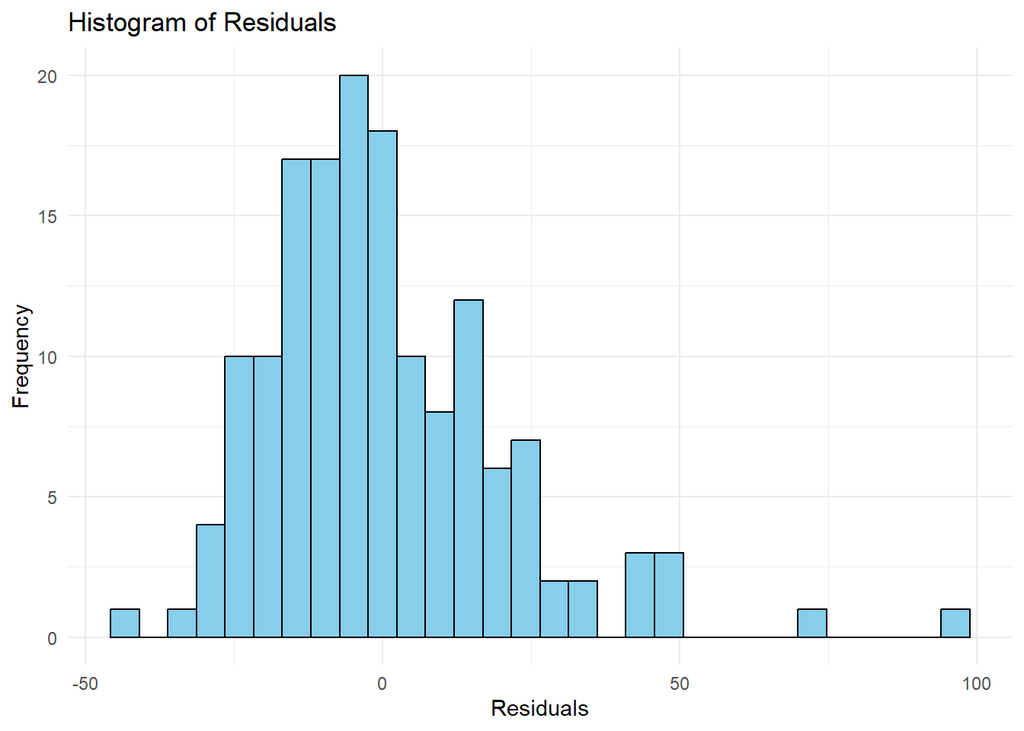

    ```r
    library(ggplot2)

    residuals <- augmented_data$.resid

    histogram_plot <- ggplot(augmented_data, aes(x = .resid)) +
      geom_histogram(bins = 30, fill = "skyblue", color = "black") +
      theme_minimal() +
      labs(title = "Histogram of Residuals", x = "Residuals", y = "Frequency")

    qqplot <- ggplot(augmented_data, aes(sample = .resid)) +
      geom_qq() +
      geom_qq_line() +
      theme_minimal() +
      labs(title = "QQ Plot of Residuals")

    histogram_plot
    ```

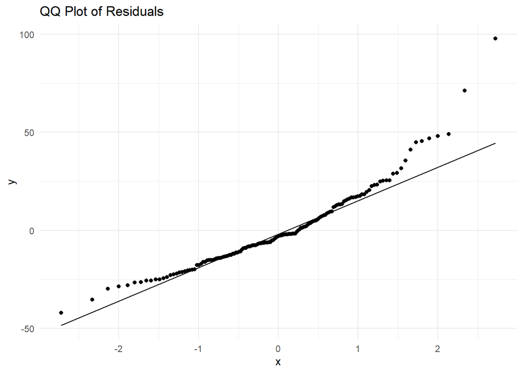

```r
qqplot
```

I used the code above to extract the residuals and visualize their distribution as a histogram and qqplot.

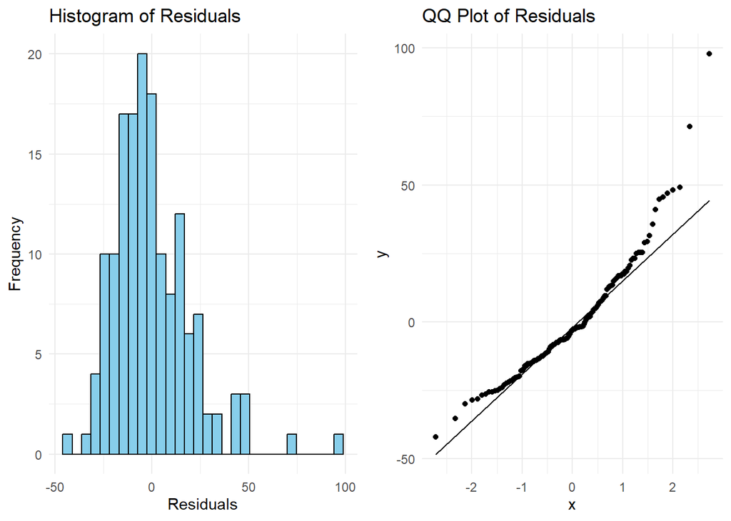

```r
library(ggpubr)
ggarrange(histogram_plot, qqplot, ncol = 2, nrow = 1)
```

17. I used the code above to plot the histogram and scatterplot as one image. I interpret from these images that the data is not normally distributed, so the model may not be accurately capturing the data.

[output not shown]